# Storms

# 1 Storm analysis

This document describes the analysis of the effect of storms on US health and the economy. Chapters in this document are:  
Chapter 2: Synopsis  
Chapter 3: Data processing  
Chapter 4: Results

The research questions that are analysed are:  
1. Across the United States, which types of events (as indicated in the EVTYPE variable) are most harmful with respect to population health?  
2. Across the United States, which types of events have the greatest economic consequences?

# 2. Synopsis

From our analysis we conclude that event types pertaining to floods, heat and lightning cause the most fatalitities and injuries. Specific for fatalitities the event type “Excessive heat” causes the most fatalities. Floods cause the most injuries.

When looking at the property damage done, we can see that floods cause the most damage, followed by hurricanes and flash floods.

# 3. Data Processing

## Location of the scrip

The script should be run in the same folder as the dataset (repdata_data_StormData.csv.bz2).

```r
setwd("E:\\Dev\\R\\Coursera\\5 Reproducible Research\\Reproducible-Research-Project-Storm\\")
```

## Setting up packages and environment

```r
# Load packages we are going to work with
library(data.table)
library(dplyr)          # Working with tables
library(ggplot2)        # Working with plots
library(R.utils)

# Set the locale the english
Sys.setlocale("LC_TIME", "English")
```

## Reading the bz2 zipped csv file

```r
# Unzip the bz2 file if the csv doesn't yet exist
if(file.exists("repdata-data-StormData.csv")==FALSE) {
        bunzip2("repdata_data_StormData.csv.bz2", "repdata-data-StormData.csv")
}

# Read the CSV file
csv <- read.csv("repdata-data-StormData.csv")
```

```r
# Convert to a dataframe table
csvdt <- tbl_df(csv)

# Remove the csv table to cleanup memory
rm(csv)

# Create a field that converts the damage exponent to a multiplication number
csvdt <- mutate(csvdt, PROPDMGMULT =
                        ifelse(PROPDMGEXP=="B"
                               ,1000000000
                               , ifelse(PROPDMGEXP=="M"
                                        , 1000000
                                        , ifelse(PROPDMGEXP=="K"
                                                 , 1000
                                                 , 1)
                                        )
                               )
                )

# Create a field for total property damage which is the damage * the multiplier
csvdt <- mutate(csvdt, PROPDMGTOT = PROPDMG * PROPDMGMULT)
```

## Cleaning the event type field

We are going to cleanup the data in the event type field. After that we’ll use a event type table from the NCDC to recreate a new event type field.

The used event type table can be found here:  
http://www1.ncdc.noaa.gov/pub/data/swdi/stormevents/csvfiles/Storm-Data-Export-Format.docx

```r
# Cleanup
csvdt <- mutate(csvdt, EVTYPE = gsub("^\\s+|\\s+$", "", EVTYPE)) # Remove starting and trailing spaces
csvdt <- mutate(csvdt, EVTYPE = toupper(EVTYPE)) # Convert all type to uppercase

# number of event types after cleanup
length(unique(csvdt$EVTYPE))
```

```
## [1] 890
```

```r
# Use regex to create a new event type
csvdt <- mutate(csvdt, EVENTTYPE = ifelse(
        grepl(".*EXTREME.*COLD.*WIND.*CHILL.*"        , EVTYPE)         , "Extreme Cold/Wind Chill", ifelse(
        grepl(".*MARINE.*HAIL.*"                        , EVTYPE)         , "Marine Hail", ifelse(
        grepl(".*MARINE.*HIGH.*WIND.*"                , EVTYPE)         , "Marine High Wind", ifelse(
        grepl(".*MARINE.*STORING.*WIND.*"               , EVTYPE)        , "Marine Strong Wind",  ifelse(
        grepl(".*MARINE.*THUNDERSTORM.*WIND.*"        , EVTYPE)         , "Marine Thunderstorm Wind", ifelse(
        grepl(".*COLD.*WIND.*CHILL.*"                , EVTYPE)         , "Cold/Wind Chill", ifelse(
        grepl(".*COLD.*WIND.*CHILL.*"                , EVTYPE)         , "Cold/Wind Chill", ifelse(
        grepl(".*DEBRIS.*FLOW.*"                        , EVTYPE)         , "Debris Flow", ifelse(
        grepl(".*DENSE.*SMOKE.*"                        , EVTYPE)         , "Dense Smoke", ifelse(
        grepl(".*DROUGHT.*"                                , EVTYPE)         , "Drought", ifelse(
        grepl(".*DUST.*DEVIL.*"                        , EVTYPE)        , "Dust Devil", ifelse(
        grepl(".*DUST.*STORM.*"                        , EVTYPE)        , "Dust Storm", ifelse(
        grepl(".*EXCESSIVE.*HEAT.*"                        , EVTYPE)        , "Excessive Heat", ifelse(
        grepl(".*LOW.*TIDE.*"                        , EVTYPE)        , "Astronomical Low Tide", ifelse(
        grepl(".*FLASH.*FLOOD.*"                        , EVTYPE)        , "Flash Flood",  ifelse(
        grepl(".*FROST.*FREEZE.*"                        , EVTYPE)        , "Frost/Freeze",  ifelse(
        grepl(".*FUNNEL.*CLOUD.*"                        , EVTYPE)        , "Funnel Cloud", ifelse(
        grepl(".*FREEZING.*FOG.*"                        , EVTYPE)        , "Freezing Fog", ifelse(
        grepl(".*DUST.*STORM.*"                        , EVTYPE)        , "Dust Storm", ifelse(
        grepl(".*HEAVY.*RAIN.*"                        , EVTYPE)        , "Heavy Rain", ifelse(
        grepl(".*HEAVY.*SNOW.*"                        , EVTYPE)        , "Heavy Snow", ifelse(
        grepl(".*HIGH.*SURF.*"                        , EVTYPE)        , "High Surf", ifelse(
        grepl(".*HIGH.*WIND.*"                        , EVTYPE)        , "High Wind", ifelse(
        grepl(".*HURRICANE.*"                        , EVTYPE)        , "Hurricane", ifelse(
        grepl(".*ICE.*STORM.*"                        , EVTYPE)        , "Ice Storm", ifelse(
        grepl(".*LAKE.*SNOW.*"                        , EVTYPE)        , "Lake-Effect Snow", ifelse(
        grepl(".*LAKE.*FLOOD.*"                        , EVTYPE)        , "Lakeshore Flood", ifelse(
        grepl(".*LIGHTNING.*"                        , EVTYPE)        , "Lightning", ifelse(
        grepl(".*FROST.*FREEZE.*"                        , EVTYPE)        , "Frost/Freeze", ifelse(
        grepl(".*SEICHE.*"                                , EVTYPE)        , "Seiche", ifelse(
        grepl(".*SLEET.*"                                , EVTYPE)        , "Sleet", ifelse(
        grepl(".*FREEZING.*FOG.*"                        , EVTYPE)        , "Freezing Fog", ifelse(
        grepl(".*THUNDERSTORM.*WIND.*"                , EVTYPE)        , "Thunderstorm Wind", ifelse(
        grepl(".*TROPICAL.*DEPRESSION.*"                , EVTYPE)        , "Tropical Depression", ifelse(
        grepl(".*TROPICAL.*STORM.*"                , EVTYPE)        , "Tropical Storm", ifelse(
        grepl(".*TSUNAMI.*"                        , EVTYPE)        , "Tsunami", ifelse(
        grepl(".*VOLCANIC.*ASH.*"                        , EVTYPE)        , "Volcanic Ash", ifelse(
        grepl(".*WATERSPOUT.*"                        , EVTYPE)        , "Waterspout", ifelse(
        grepl(".*WILDFIRE.*"                        , EVTYPE)        , "Wildfire", ifelse(
        grepl(".*WINTER.*STORM.*"                        , EVTYPE)        , "Winter Storm", ifelse(
        grepl(".*WINTER.*WEATHER.*"                        , EVTYPE)        , "Winter Weather", ifelse(
        grepl(".*AVALANCHE.*"                        , EVTYPE)        , "Avalanche", ifelse(
        grepl(".*BLIZZARD.*"                        , EVTYPE)        , "Avalanche", ifelse(
        grepl(".*FLOOD.*"                                , EVTYPE)        , "Flood", ifelse(
        grepl(".*HEAT.*"                                , EVTYPE), "Heat", "Others"
        ))))))))))))))))))))))))))))))))))))))))))))))

# Check the new unique event types based on the new event type [EVENTTYPE]
unique(csvdt$EVENTTYPE)
```

```
##  [1] "Others"                   "Flash Flood"
##  [3] "Winter Storm"             "High Wind"
##  [5] "Thunderstorm Wind"        "Hurricane"
##  [7] "Heavy Rain"               "Lightning"
##  [9] "Funnel Cloud"             "Heat"
## [11] "Flood"                    "Waterspout"
## [13] "Avalanche"                "Heavy Snow"
## [15] "Ice Storm"                "Dust Storm"
## [17] "Sleet"                    "Dust Devil"
## [19] "Excessive Heat"           "High Surf"
## [21] "Winter Weather"           "Drought"
## [23] "Tropical Storm"           "Wildfire"
## [25] "Lakeshore Flood"          "Lake-Effect Snow"
## [27] "Frost/Freeze"             "Freezing Fog"
## [29] "Volcanic Ash"             "Astronomical Low Tide"
## [31] "Cold/Wind Chill"          "Seiche"
## [33] "Tropical Depression"      "Extreme Cold/Wind Chill"
## [35] "Marine Hail"              "Marine High Wind"
## [37] "Tsunami"                  "Dense Smoke"
## [39] "Marine Thunderstorm Wind"
```

```r
length(unique(csvdt$EVENTTYPE))
```

```
## [1] 39
```

# 4. Results

## Most harmfull events to population health

Question: Across the United States, which types of events (as indicated in the EVTYPE variable) are most harmful with respect to population health?

Approach:  
* We will take a look at both the number of fatalities and injuries  
* We’ll leave the “Others” event type out of the analysis  
* Only event types with more then 0 fatalities or injuries will be shown

### Analysis on fatalities

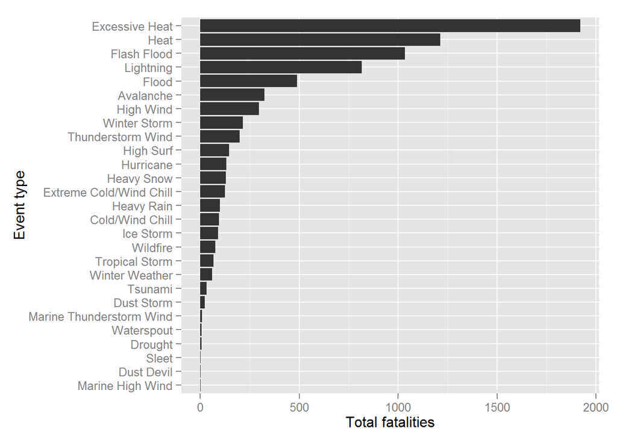

```r
# Create a table for the effect of event types on fatalities
fatalities<-
        csvdt %>%
        group_by(EVENTTYPE) %>% # Group the data by event type
        summarize(fatalities_tot = sum(FATALITIES)) %>% #Summarize a total
        filter(fatalities_tot > 0) %>% #Filter out event types with 0 fatalities
        filter(EVENTTYPE != "Others") %>% #Filter out the event type "Others"
        arrange(desc(fatalities_tot)) %>%
        mutate(EVENTTYPE = factor(EVENTTYPE))

# Plot the fatalities per event type
ggplot(fatalities, aes(x=reorder(EVENTTYPE,fatalities_tot), y= fatalities_tot)) + geom_bar(stat= "identity", binwidth = 1) + coord_flip() + labs(x='Event type',y='Total fatalities')
```

Graph caption: we can see that Excessive heat causes the most fatalities with the next event type being heat related.

### Analysis on injuries

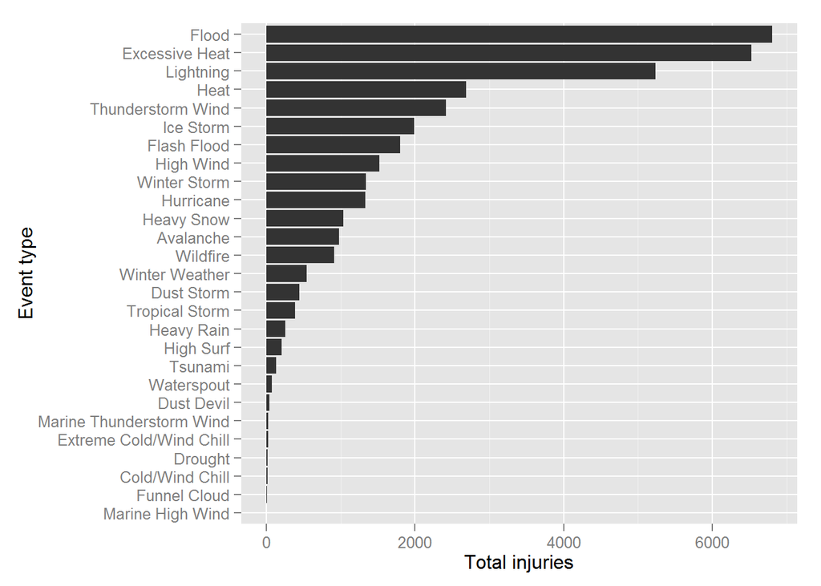

```r
# Create a table for the effect of event types on injuries
injuries<-
        csvdt %>%
        group_by(EVENTTYPE) %>% # Group the data by event type
        summarize(injuries_tot = sum(INJURIES)) %>% #Summarize a total
        filter(injuries_tot > 0) %>% #Filter out event types with 0 fatalities
        filter(EVENTTYPE != "Others") %>% #Filter out the event type "Others"
        arrange(desc(injuries_tot)) %>%
        mutate(EVENTTYPE = factor(EVENTTYPE))

# Plot the injuries per event type
ggplot(injuries, aes(x=reorder(EVENTTYPE,injuries_tot), y= injuries_tot)) + geom_bar(stat= "identity", binwidth = 1) + coord_flip() + labs(x='Event type',y='Total injuries')
```

Graph caption: we can see that floods cause the most casualties.

## Events with the largets economic consequences

Question: Across the United States, which types of events have the greatest economic consequences?

Approach: * We will analyse the economic consequences by analyzing the total of property damage events have caused.  
* We already calculated the total property damage in the field PROPDMGTOT.

### Analysis on property damage

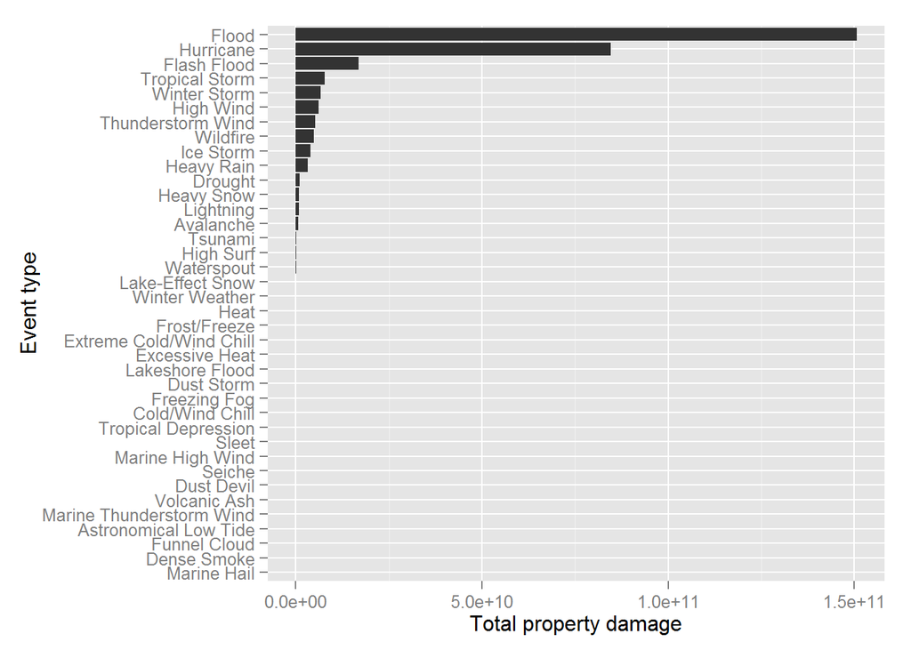

```r
# Create a table for the effect of event types on property damage
propdam<-
        csvdt %>%
        group_by(EVENTTYPE) %>% # Group the data by event type
        summarize(propdam_tot = sum(PROPDMGTOT)) %>% #Summarize a total
        filter(propdam_tot > 0) %>% #Filter out event types with 0 damage
        filter(EVENTTYPE != "Others") %>% #Filter out the event type "Others"
        arrange(desc(propdam_tot)) %>%
        mutate(EVENTTYPE = factor(EVENTTYPE))

# Plot the injuries per event type
ggplot(propdam, aes(x=reorder(EVENTTYPE,propdam_tot), y= propdam_tot)) + geom_bar(stat= "identity", binwidth = 1) + coord_flip() + labs(x='Event type',y='Total property damage')
```

```r
# Total damage for the nr 1 event type (in B = billions)
(max(propdam$propdam_tot)/1000000000)
```

```
## [1] 150.5933
```

Graph caption: we can see that floods cause the most economic damage when looking at the property damage.